# Assignment 2 - The tidyverse

Elena Garcia Manes

octubre 05, 2021 | 15:38:51 | CEST

```r
# LOAD THE PACKAGES YOU ARE USING IN THIS CODE CHUNK library(nameofpackage)
library(tidyverse)
library(legislatoR)
library(lubridate)
```

### Getting started with the Comparative Legislators Database

The Comparative Legislators Database (CLD) includes political, sociodemographic, career, online presence, public attention, and visual information for over 45,000 contemporary and historical politicians from ten countries (see the [corresponding article](https://www.cambridge.org/core/journals/british-journal-of-political-science/article/comparative-legislators-database/D28BB58A8B2C08C8593DB741F42C18B2) for more information). It can be accessed via `legislatoR` - an R package that is available on both [CRAN](https://cran.r-project.org/web/packages/legislatoR/index.html) and [GitHub](https://github.com/saschagobel/legislatoR).

Before you start with the following tasks, skim the tutorial to make yourself familiar with the database. You find it [here](https://cran.r-project.org/web/packages/legislatoR/vignettes/legislatoR.html).

For the following tasks, you will work with ONE of the legislatures. The legislature you’ll work with depends on your prename:

| Your prename starts with… | Legislature | Code |
| --- | --- | --- |
| A-C | Austrian Nationalrat | `aut` |
| D-F | Canadian House of Commons | `can` |
| G-I | Czech Poslanecka Snemovna | `cze` |
| J-L | Spanish Congreso de los Diputados | `esp` |
| M-O | French Assemblée | `fra` |
| P-R | German Bundestag | `deu` |
| S-U | Irish Dail | `irl` |
| V-X | UK House of Commons | `gbr` |
| Y-Z | US House of Representatives | `usa_house` |

The following tasks will be based on data from the `core` and `political` tables of the database.

### Task 1 - Fun with descriptives [8 points in total]

1. What’s the overall share of female legislators in the entire dataset? [1 point]

```r
#Getting an overview of functions available in legislatoR
?legislatoR()

#Getting "Core" table for the Canadian House of Commons
can_house_core <- get_core(legislature = "can")
glimpse(can_house_core)
```

```
Rows: 4,515
Columns: 12
$ country    <chr> "CAN", "CAN", "CAN", "CAN", "CAN", "CAN", "CAN", "CAN", "CA…
$ pageid     <chr> "3608006", "1545901", "3589671", "2095757", "237612", "7067…
$ wikidataid <chr> "Q8010740", "Q5931769", "Q6131249", "Q633347", "Q351904", "…
$ wikititle  <chr> "William_Hallett_Ray", "Hugh_McDonald_(politician)", "James…
$ name       <chr> "William Hallett Ray", "Hugh McDonald", "James Charles McKe…
$ sex        <chr> "male", "male", "male", "male", "male", "male", "male", "ma…
$ ethnicity  <chr> "white", "white", NA, "white", "white", NA, "white", "white…
$ religion   <chr> NA, NA, NA, NA, NA, NA, "protestantism baptist", NA, NA, NA…
$ birth      <dttm> 1825-05-25, 1827-05-04, 1815-01-01, 1824-12-20, 1814-05-03…
$ death      <dttm> 1909-05-07, 1899-02-28, 1879-09-14, 1890-06-26, 1892-12-14…
$ birthplace <chr> "44.6671,-65.6107", NA, "54.61,-7.16", "45.4752,-63.6024", …
$ deathplace <chr> "44.6671,-65.6107", "45.62652,-61.99825", "45.07399,-67.052…
```

```r
#Getting "Political" table for the Canadian House of Commons
can_political <- get_political(legislature = "can")
glimpse(can_political)
```

```
Rows: 11,927
Columns: 15
$ pageid            <chr> "3608006", "1545901", "3589671", "2095757", "237612"…
$ session           <int> 1, 1, 1, 1, 1, 1, 1, 1, 1, 1, 1, 1, 1, 1, 1, 1, 1, 1…
$ party             <chr> "Liberal Party of Canada", "Liberal-Conservative Par…
$ constituency      <chr> "Annapolis", "Antigonish", "Cape Breton", "Colcheste…
$ constituency2     <chr> "Nova Scotia", "Nova Scotia", "Nova Scotia", "Nova S…
$ session_start     <date> 1867-09-20, 1867-09-20, 1867-09-20, 1867-09-20, 186…
$ session_end       <date> 1872-10-11, 1872-10-11, 1872-10-11, 1872-10-11, 187…
$ service           <int> 1848, 1848, 1848, 640, 252, 703, 1848, 1848, 1848, 1…
$ government        <lgl> FALSE, FALSE, FALSE, FALSE, FALSE, FALSE, TRUE, TRUE…
$ opposition        <lgl> TRUE, FALSE, FALSE, FALSE, FALSE, TRUE, FALSE, FALSE…
$ third             <lgl> FALSE, TRUE, TRUE, TRUE, TRUE, FALSE, FALSE, FALSE, …
$ unrecognized      <lgl> FALSE, FALSE, FALSE, FALSE, FALSE, FALSE, FALSE, FAL…
$ prime_minister    <lgl> FALSE, FALSE, FALSE, FALSE, FALSE, FALSE, FALSE, FAL…
$ opposition_leader <lgl> FALSE, FALSE, FALSE, FALSE, FALSE, FALSE, FALSE, FAL…
$ speaker           <lgl> FALSE, FALSE, FALSE, FALSE, FALSE, FALSE, FALSE, FAL…
```

```r
#Filtering female & calculating the percentage
female <- can_house_core %>%
  filter(sex== "female")

share_female <- round(nrow(female)/nrow(can_house_core)*100, 2)
```

**7.8%** of legislators in the entire dataset are **female**.

2. How many (both in absolute and relative terms) legislators died in the same place they were born in? [1 point]

```r
#Filtering only those whose birth and death place is the same & calculating the percentage
birth_death <- can_house_core %>%
  filter(birthplace==deathplace)

abs_birth_death <- nrow(birth_death)

share_birth_death <- round(abs_birth_death/nrow(can_house_core)*100, 2)
```

**152 legislators** died in the same place they were born in, which is **3.37%** of total legislators.

3. Create a new variable `age_at_death` that reports the age at which legislators died. Then, plot the distribution of that variable for the entire dataset. [2 points]

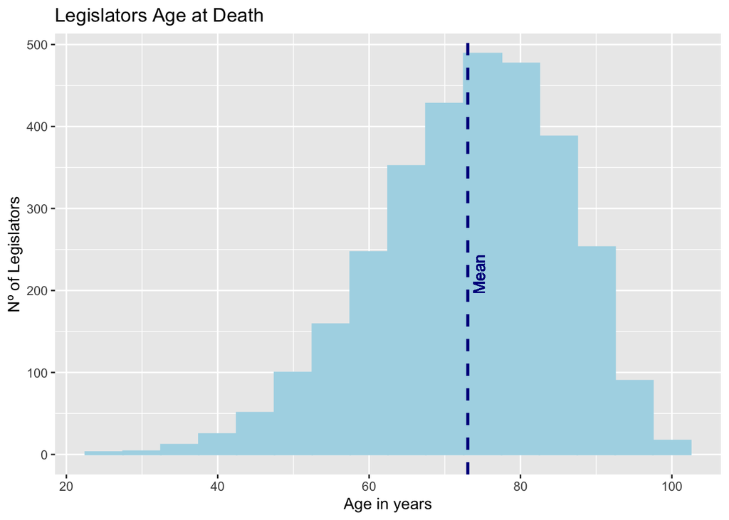

```r
#Creating a column with the age at death
can_house_core <-can_house_core %>% mutate(age_at_death = round((death - birth)/365,2))

#Plotting an histogram highlighting the mean
ggplot(can_house_core, aes(x= age_at_death)) +
  geom_histogram(binwidth = 5, colour= "lightblue", fill="lightblue") +
  geom_vline(aes(xintercept=mean(age_at_death, na.rm=T)),
               color="darkblue", linetype="dashed", size=1) +
  labs(title = "Legislators Age at Death", x="Age in years", y= "Nº of Legislators") +
  geom_text(aes(x=mean(can_house_core$age_at_death, na.rm=T), label="Mean", y=220), colour="darkblue", angle=90, vjust = 1.5, text=element_text(size=3))
```

4. Provide one single table that provides the 5 legislators with the highest and lowest age at death, ignoring ties. [2 points]

```r
#Highest age at death: filter & arrange
highest_age_death <- can_house_core %>%
  filter(!is.na(age_at_death)) %>%
  arrange(desc(age_at_death)) %>%
  head(5)

#Lowest age at death: filter & arrange
lowest_age_death <- can_house_core %>%
  filter(!is.na(age_at_death)) %>%
  arrange(desc(age_at_death)) %>%
  tail(5)

#Joint table
rbind(highest_age_death, lowest_age_death)
```

|  | country | pageid | wikidataid | wikititle | name | sex | ethnicity | religion | birth | death | birthplace | deathplace | age_at_death |
| --- | --- | --- | --- | --- | --- | --- | --- | --- | --- | --- | --- | --- | --- |
| 1 | CAN | 207073 | Q8015915 | William_Mulock | William Mulock | male | white | NA | 1843-01-19 | 1944-10-01 | 44.1333,-79.6333 | 43.7,-79.4 | 101.77 days |
| 2 | CAN | 19116962 | Q5083621 | Charles_Willoughby_(politician) | Charles James McNeil Willoughby | male | NA | NA | 1894-03-30 | 1995-09-05 | 44.3,-79.5833 | 50.6761,-120.341 | 101.50 days |
| 3 | CAN | 18280608 | Q7427281 | Saul_Bonnell | Saul Bonnell | male | white | NA | 1871-12-29 | 1973-03-21 | NA | 49.25,-123.1 | 101.29 days |
| 4 | CAN | 14261557 | Q5026359 | Cameron_Ross_McIntosh | Cameron Ross McIntosh | male | NA | NA | 1871-07-07 | 1971-08-08 | 57.88,-4.03 | 56,-109 | 100.15 days |
| 5 | CAN | 774942 | Q434334 | Ellen_Fairclough | Ellen Fairclough | female | NA | NA | 1905-01-28 | 2004-11-13 | 43.25667,-79.86917 | 43.25667,-79.86917 | 99.86 days |
| 3091 | CAN | 21634054 | Q3184146 | Joseph-Aimé_Massue | Joseph-Aimé Massue | male | NA | NA | 1860-10-18 | 1891-04-10 | NA | NA | 30.50 days |
| 3092 | CAN | 7106542 | Q8013771 | William_Joseph_Croke | William Croke | male | NA | NA | 1840-01-01 | 1869-03-11 | NA | NA | 29.21 days |
| 3093 | CAN | 17019367 | Q3579702 | Édouard_H._Léger | Édouard H. Léger | male | white | NA | 1866-04-23 | 1892-08-08 | 46.2737,-64.5757 | NA | 26.31 days |
| 3094 | CAN | 12526944 | Q3259503 | Lorenzo_Robitaille | Lorenzo Robitaille | male | white | NA | 1882-05-27 | 1906-01-01 | 46.81611,-71.22417 | 45.50889,-73.56167 | 23.61 days |
| 3095 | CAN | 9809147 | Q3048524 | Edward_Goff_Penny | Edward Goff Penny | male | NA | NA | 1858-05-15 | 1881-10-11 | 51.544,-0.1027 | 45.50889,-73.56167 | 23.42 days |

5. Find out who has got the longest name and who the shortest (both in terms of number of characters, ignoring whitespace)! [2 points]

```r
#Creating a column to display the nª of characters excluding whitespace & checking HEAD
can_house_core %>%
  mutate(name_lenght = nchar(can_house_core$name) - str_count(can_house_core$name, pattern = " ")) %>%
  arrange(desc(name_lenght)) %>%
  head(1)
```

|  | country | pageid | wikidataid | wikititle | name | sex | ethnicity | religion | birth | death | birthplace | deathplace | age_at_death | name_lenght |
| --- | --- | --- | --- | --- | --- | --- | --- | --- | --- | --- | --- | --- | --- | --- |
| 1 | CAN | 8544607 | Q3102133 | Georges-Raoul-Léotale-Guichart-Humbert_Saveuse_de_Beaujeu | Georges-Raoul-Léotale-Guichart-Humbert Saveuse de Beaujeu | male | NA | NA | 1847-06-22 | 1887-12-15 | 45.35,-74.21667 | NA | 40.51 days | 54 |

```r
#Creating a column to display the nª of characters excluding whitespace & checking TAIL
can_house_core %>%
  mutate(name_lenght = nchar(can_house_core$name) - str_count(can_house_core$name, pattern = " ")) %>%
  arrange(desc(name_lenght)) %>%
  tail(1)
```

|  | country | pageid | wikidataid | wikititle | name | sex | ethnicity | religion | birth | death | birthplace | deathplace | age_at_death | name_lenght |
| --- | --- | --- | --- | --- | --- | --- | --- | --- | --- | --- | --- | --- | --- | --- |
| 4515 | CAN | 53682214 | Q29139548 | Mary_Ng | Mary Ng | female | NA | NA | 1969-12-16 |  | 22.27833,114.15861 | NA | NA days | 6 |

The legislator with the longest name is **Georges-Raoul-Léotale-Guichart-Humbert Saveuse de Beaujeu** and the one with the shortest is **Mary Ng**.

### Task 2 - Exploring trends in the data [8 points in total]

1. Using data from all sessions, provide a plot that shows the share of female legislators by session! [3 points]

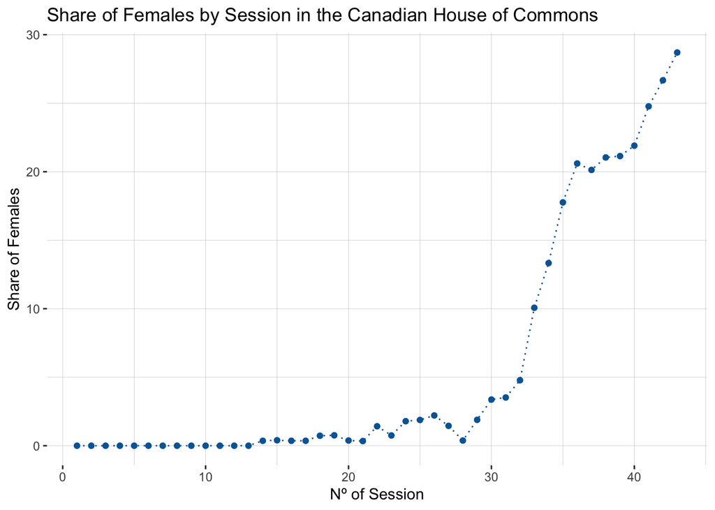

```r
#Join the datasets using "pageid"
female_by_session <- left_join(
  can_political,
  can_house_core,
  by = "pageid" ) %>%
  group_by(session) %>%
  summarise(female_share = round(sum(sex == "female", na.rm = T)/n()*100,2))

#Plotting
ggplot(female_by_session, aes(x=session, y=female_share))+
  geom_line(linetype="dotted", color="#0067A5") +
  geom_point(color= "#0067A5") +
  theme(panel.background = element_rect(fill="white"), panel.grid.major = element_line(size = 0.1, linetype = 'solid',
                                colour = "grey"),
  panel.grid.minor = element_line(size = 0.1, linetype = 'solid',
                                colour = "grey")) +
    labs(title = "Share of Females by Session in the Canadian House of Commons", x="Nº of Session", y= "Share of Females")
```

2. Explore another relation of variables in the dataset. Your analysis should (i) use data from both the `core` and the `political` table and (ii) feature data from several sessions. Also, offer a brief description and interpretation of your findings! [5 points]

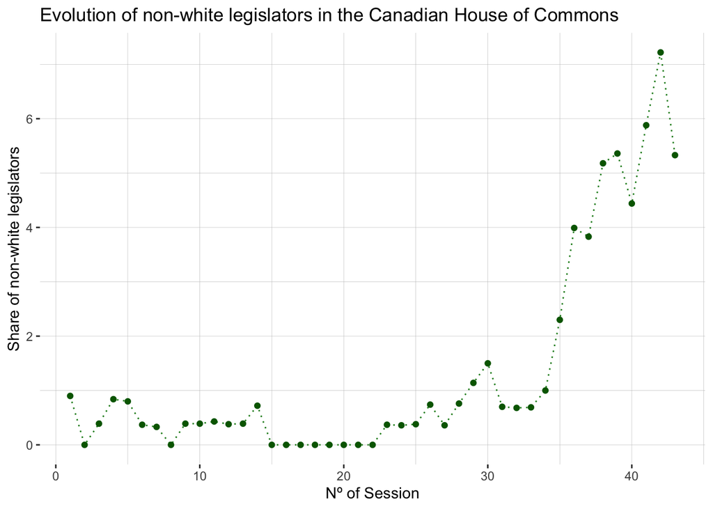

```r
#Join the datasets
ethnicity_non_white_share <- left_join(
  can_political,
  can_house_core,
  by = "pageid" ) %>%
  group_by(session) %>%
  summarise(non_white_share = round(sum(ethnicity == "arab", ethnicity == "asian",  ethnicity == "black",  ethnicity == "hispanic", ethnicity == "native", na.rm = T)/n()*100,2))

#Plotting
ggplot(ethnicity_non_white_share, aes(x=session, y=non_white_share))+
  geom_line(linetype="dotted", color="forestgreen") +
  geom_point(color= "darkgreen") +
  theme(panel.background = element_rect(fill="white"), panel.grid.major = element_line(size = 0.1, linetype = 'solid',
                                colour = "grey"),
  panel.grid.minor = element_line(size = 0.1, linetype = 'solid',
                                colour = "grey")) +
    labs(title = "Evolution of non-white legislators in the Canadian House of Commons", x="Nº of Session", y= "Share of non-white legislators")
```

We are interested in the **diversity of the Canadian House of Commons**. In previous steps in our analysis, we detected a striking lack of gender diversity preceding session 30 (1974). To get a grasp of **ethnic diversity**, we obtain the share of non-white legislators (which includes *arab*, *asian*, *black*, *hispanic* and *native* legislators) by session to plot a visual representation of how has the presence of non-white legislators evolved over time.

The trend is similar to the presence of women in Parliament: session 30 marks an upward trend in the diversification of the House. However, the share of non-white legislators —peaking just above 7% in session 42— is remarkably low considering that Statistics Canada (official agency of the Government of Canada) reported that 22.3% of the country population identified as “non-white”.

### Task 3 - Fun with functions [3 points in total]

1. Program a function `ultimate_answer()` that always returns the number 42, and prove that it works! [1 point]

```r
ultimate_answer <- function(x){
  return(42)}

ultimate_answer(5)
```

```
[1] 42
```

```r
ultimate_answer(TRUE)
```

```
[1] 42
```

```r
ultimate_answer("border_collie")
```

```
[1] 42
```

2. Program a robust function `normalize()` that normalizes a numeric vector x to mean(x) = 0 and sd(x) = 1! Then, apply it to all numeric variables in the mtcars dataset! [2 points]

```r
normalize <- function(x){
  x=x-mean(x)
  x=x/sd(x)
  return(x)
}

mtcars %>%
  mutate(across(c(mpg, disp, hp, drat,wt,qsec),normalize))
```

|  | mpg | cyl | disp | hp | drat | wt | qsec | vs | am | gear | carb |
| --- | --- | --- | --- | --- | --- | --- | --- | --- | --- | --- | --- |
| Mazda RX4 | 0.15088482 | 6 | -0.57061982 | -0.53509284 | 0.56751369 | -0.610399567 | -0.77716515 | 0 | 1 | 4 | 4 |
| Mazda RX4 Wag | 0.15088482 | 6 | -0.57061982 | -0.53509284 | 0.56751369 | -0.349785269 | -0.46378082 | 0 | 1 | 4 | 4 |
| Datsun 710 | 0.44954345 | 4 | -0.99018209 | -0.78304046 | 0.47399959 | -0.917004624 | 0.42600682 | 1 | 1 | 4 | 1 |
| Hornet 4 Drive | 0.21725341 | 6 | 0.22009369 | -0.53509284 | -0.96611753 | -0.002299538 | 0.89048716 | 1 | 0 | 3 | 1 |
| Hornet Sportabout | -0.23073453 | 8 | 1.04308123 | 0.41294217 | -0.83519779 | 0.227654255 | -0.46378082 | 0 | 0 | 3 | 2 |
| Valiant | -0.33028740 | 6 | -0.04616698 | -0.60801861 | -1.56460776 | 0.248094592 | 1.32698675 | 1 | 0 | 3 | 1 |
| Duster 360 | -0.96078893 | 8 | 1.04308123 | 1.43390296 | -0.72298087 | 0.360516446 | -1.12412636 | 0 | 0 | 3 | 4 |
| Merc 240D | 0.71501778 | 4 | -0.67793094 | -1.23518023 | 0.17475447 | -0.027849959 | 1.20387148 | 1 | 0 | 4 | 2 |
| Merc 230 | 0.44954345 | 4 | -0.72553512 | -0.75387015 | 0.60491932 | -0.068730634 | 2.82675459 | 1 | 0 | 4 | 2 |
| Merc 280 | -0.14777380 | 6 | -0.50929918 | -0.34548584 | 0.60491932 | 0.227654255 | 0.25252621 | 1 | 0 | 4 | 4 |

[output cut: 22 more lines]